# Hayward Time Series Analysis and Labor Force Classification

# Part II. Classification Analysis

- Plan to a logistic regression classification, a XGBoost classification, and a Keras Neural Network classification.

## B.) Regression/Machine Learning

Use the data provided to create a model that predicts labor force participation (inlf variable in the dataset).  
You are free to use any combination of the other variables for this prediction.  
Here is a list of the included variables and their descriptions.

[figure not shown]

Back to Top

## Exploratory Data Analysis

```python
labordata = pd.read_csv("data_B.csv")
```

```python
labordata.head()
```

|  | inlf | hours | kidslt6 | kidsge6 | age | educ | wage | repwage | hushrs | husage | huseduc | huswage | faminc | mtr | motheduc | fatheduc | unem | city | exper | nwifeinc | lwage | expersq |
| --- | --- | --- | --- | --- | --- | --- | --- | --- | --- | --- | --- | --- | --- | --- | --- | --- | --- | --- | --- | --- | --- | --- |
| 0 | 1 | 1610 | 1 | 0 | 32 | 12 | 3.3540 | 2.65 | 2708 | 34 | 12 | 4.0288 | 16310 | 0.7215 | 12 | 7 | 5.0 | 0 | 14 | 10.910060 | 1.210154 | 196 |
| 1 | 1 | 1656 | 0 | 2 | 30 | 12 | 1.3889 | 2.65 | 2310 | 30 | 9 | 8.4416 | 21800 | 0.6615 | 7 | 7 | 11.0 | 1 | 5 | 19.499981 | 0.328512 | 25 |
| 2 | 1 | 1980 | 1 | 3 | 35 | 12 | 4.5455 | 4.04 | 3072 | 40 | 12 | 3.5807 | 21040 | 0.6915 | 12 | 7 | 5.0 | 0 | 15 | 12.039910 | 1.514138 | 225 |
| 3 | 1 | 456 | 0 | 3 | 34 | 12 | 1.0965 | 3.25 | 1920 | 53 | 10 | 3.5417 | 7300 | 0.7815 | 7 | 7 | 5.0 | 0 | 6 | 6.799996 | 0.092123 | 36 |
| 4 | 1 | 1568 | 1 | 2 | 31 | 14 | 4.5918 | 3.60 | 2000 | 32 | 12 | 10.0000 | 27300 | 0.6215 | 12 | 14 | 9.5 | 1 | 7 | 20.100060 | 1.524272 | 49 |

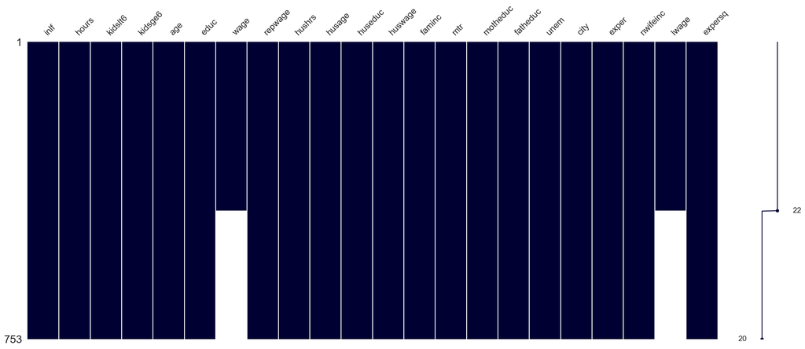

```python
msno.matrix(labordata,  color = (.0,.0,.2))
```

#### 👆🏽Thoughts about this? 👆🏽

- Using this null data visualization, we can immediately see that there is something up with the 'wage' and 'lwage' columns.
- This makes sense:
  - If you are making a wage or thus a log-transformed wage, then you must have been working in 1975. Thus, this data point is not actually predictive, and I'll soon take it out of the dataset.

```python
#missing data
total = labordata.isnull().sum().sort_values(ascending=False)
percent = (labordata.isnull().sum()/labordata.isnull().count()).sort_values(ascending=False)
missing_data = pd.concat([total, percent], axis=1, keys=['Total', 'Percent'])
missing_data.head()
```

|  | Total | Percent |
| --- | --- | --- |
| lwage | 325 | 0.431607 |
| wage | 325 | 0.431607 |
| expersq | 0 | 0.000000 |
| hours | 0 | 0.000000 |
| kidslt6 | 0 | 0.000000 |

```python
#dropping features we do not want in the analysis
labordata_processed = labordata.drop(['lwage','wage', 'repwage','hours',\
                                     'faminc','nwifeinc'], axis = 1)
#each of these feautres is basically a proxy for already being in the workforce, so they aren't predictors
#repwage happens in 1976, but we're predicting for 1975 so that has to be out
#family income and nwifeinc are backdoors for the income of the woman, who would then already be in the workforce
```

#### 👆🏽Thoughts about this? 👆🏽

- Each of these features is basically a proxy for already being in the workforce, so they aren't predictors.
- Along those lines, 'faminc' and 'nwifeinc' both take into account the wage of the person being studied, so it also gives away whether the respondent is or is not in the workforce, I've also eliminated it.
- 'Repwage' is the wage reported in 1976, but since we're predicting for being in the labor force in 1975, then it should be taken out.

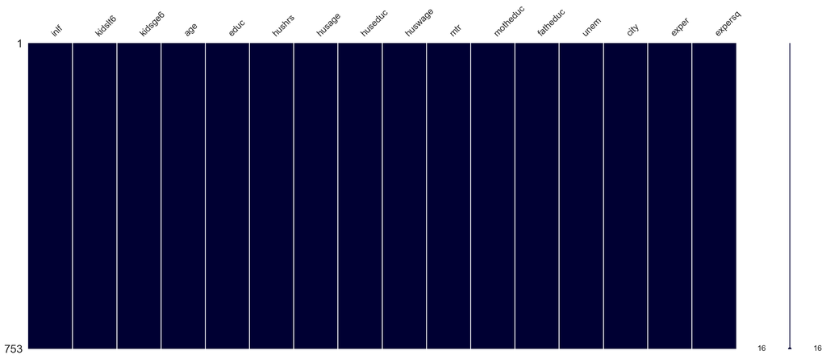

```python
msno.matrix(labordata_processed,  color = (.0,.0,.2))
```

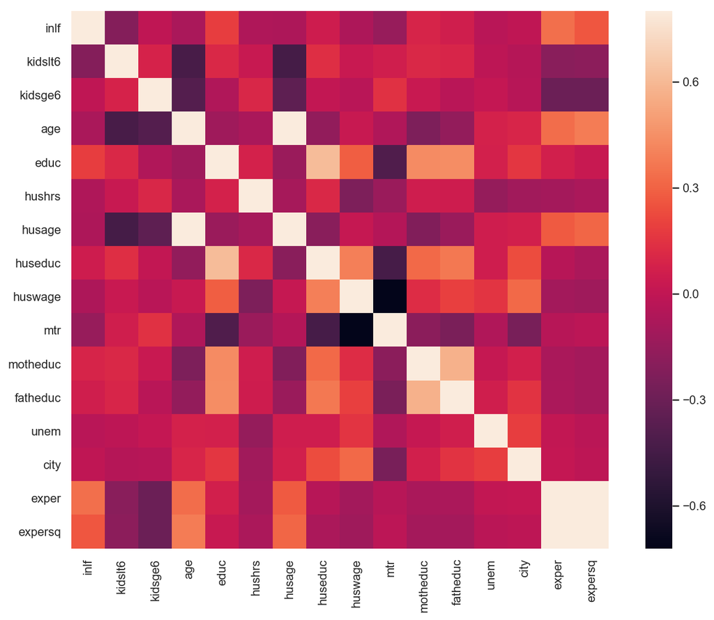

```python
#all credit due to: Pedro Marcelino
#https://www.kaggle.com/pmarcelino/comprehensive-data-exploration-with-python
#correlation matrix
corrmat = labordata_processed.corr()
f, ax = plt.subplots(figsize=(12, 9))
sns.heatmap(corrmat, vmax=.8, square=True)
plt.savefig('labor_data_correlation_matrix.png',dpi=300, bbox_inches='tight')
```

#### 👆🏽Thoughts about this? 👆🏽

- Correlation plots are great for seeing which kinds of features 'move' with each other.
- One interesting thing to see is the correlation between age and husband's age.
  - Looks like people of around the same age get married together.

```python
#all credit due to: Pedro Marcelino
#https://www.kaggle.com/pmarcelino/comprehensive-data-exploration-with-python
#scatterplot
sns.set()
#cols = ['column1', 'column2']
sns.pairplot(labordata_processed, size = 2.5)
#plt.savefig('exhibit_0b_pair_plot.png',dpi=600, bbox_inches='tight')
#600 dpi is commented out. It's useful for viewing all the data up close on your desktop, but slows down the script.
plt.savefig('labor_data_pair_plot_lower_res.png',dpi=150, bbox_inches='tight')
plt.show()
```

[figure not shown]

#### 👆🏽Thoughts about this? 👆🏽

- Pair plots are great for quickly scanning all the data and seeing realtionships.
  - We must remember that they don't take into account interactions.

```python
#address skew in features
#For this block, credit goes to Alexandru Papiu
#(https://www.kaggle.com/apapiu/regularized-linear-models)
#log transform skewed numeric features:
continous_features_classification = ['kidslt6', 'kidsge6', 'age', 'educ', 'hushrs', 'husage',\
'huseduc', 'huswage', 'mtr', 'motheduc', 'fatheduc', 'unem', 'exper', 'expersq']
#exposure units have already been taken out
skewed_feats = labordata_processed[continous_features_classification].apply(\
                                                                                lambda x: stats.skew(x))
#compute skewness
skewed_feats = skewed_feats[skewed_feats > 0.75]
skewed_feats = skewed_feats.index

labordata_processed[skewed_feats] = np.log1p(labordata_processed[skewed_feats])
```

Back to Top

## 📊 XGBoost Classification 📊

```python
#xgboost
classification_features_xgb = labordata_processed.drop(['inlf'], axis = 1)
classification_outcome_xgb = labordata_processed.inlf
train_features, test_features, train_labels, test_labels = train_test_split(classification_features_xgb,\
                                                                    classification_outcome_xgb, test_size = 0.2)

xgb_classy = xgb.XGBClassifier()

xgb_classy.fit(train_features,train_labels)

xgb_classy_predictions = xgb_classy.predict(test_features)


#run model
print("_________XGBoost Regression Classification_________")
print("")
print("Scored Against Itself")
print('Accuracy Score: {}'.format(round(xgb_classy.score(train_features, train_labels),3)))
print("")
print("Scored Against Test Data")
print('Accuracy Score: {}'.format(round(xgb_classy.score(test_features, test_labels),3)))
```

```
_________XGBoost Regression Classification_________

Scored Against Itself
Accuracy Score: 0.887

Scored Against Test Data
Accuracy Score: 0.748
```

```python
#cross-val #this will run about 70 seconds per print
print("_________Cross-Validation Scoring for XGBoost Classification_________")
print('Accuracy: {}'.format(round(cross_val_score(xgb_classy, train_features, train_labels, \
                                                                cv=10, scoring='accuracy').mean(),3)))
print('Precision: {}'.format(round(cross_val_score(xgb_classy, train_features, train_labels, \
                                                                cv=10, scoring='precision').mean(),3)))
print('Recall: {}'.format(round(cross_val_score(xgb_classy, train_features, train_labels, \
                                                                cv=10, scoring='recall').mean(),3)))
```

```
_________Cross-Validation Scoring for XGBoost Classification_________
Accuracy: 0.713
Precision: 0.739
Recall: 0.769
```

```python
top_10_xgb_features = pd.DataFrame(sorted(list(zip(classification_features_xgb,xgb_classy.feature_importances_))\
       ,key = lambda x: abs(x[1]),reverse=True)[:10], columns=['Feature', 'XGBoost Importance'])
top_10_xgb_features
```

|  | Feature | XGBoost Importance |
| --- | --- | --- |
| 0 | exper | 0.176079 |
| 1 | kidslt6 | 0.081903 |
| 2 | kidsge6 | 0.079420 |
| 3 | mtr | 0.079354 |
| 4 | motheduc | 0.075405 |
| 5 | husage | 0.074865 |
| 6 | age | 0.073868 |
| 7 | educ | 0.072686 |
| 8 | huswage | 0.063095 |
| 9 | hushrs | 0.051104 |

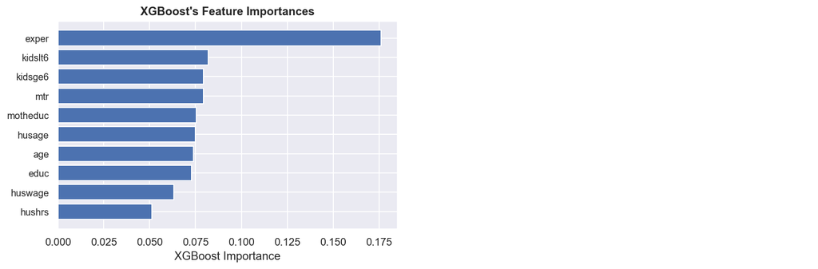

```python
#plt.xticks(rotation=-25)
bar_count = range(len(top_10_xgb_features.Feature))
fig, axs = plt.subplots(ncols=2, figsize=(14,4))
#using a subplot method coupled with an inline parameter to have high resolution
#note: "[::-1]" reverses the column in a pandas dataframe
axs[1].set_axis_off()
axs[0].barh(bar_count, top_10_xgb_features['XGBoost Importance'][::-1],\
                 align='center', alpha=1)
axs[0].set_xlabel('Values')
axs[0].set_yticks(bar_count)
axs[0].set_yticklabels(top_10_xgb_features.Feature[::-1], fontsize=10)
axs[0].set_xlabel('XGBoost Importance')
axs[0].set_title("XGBoost's Feature Importances",fontweight = 'bold')

extent = axs[0].get_window_extent().transformed(fig.dpi_scale_trans.inverted())
fig.savefig('laborforce_xgbfeatures',dpi=300, bbox_inches=extent.expanded(1.5, 1.5))
plt.show()
```

```
Accuracy: 0.7483443708609272
Precision: 0.7608695652173914
Recall: 0.813953488372093
```

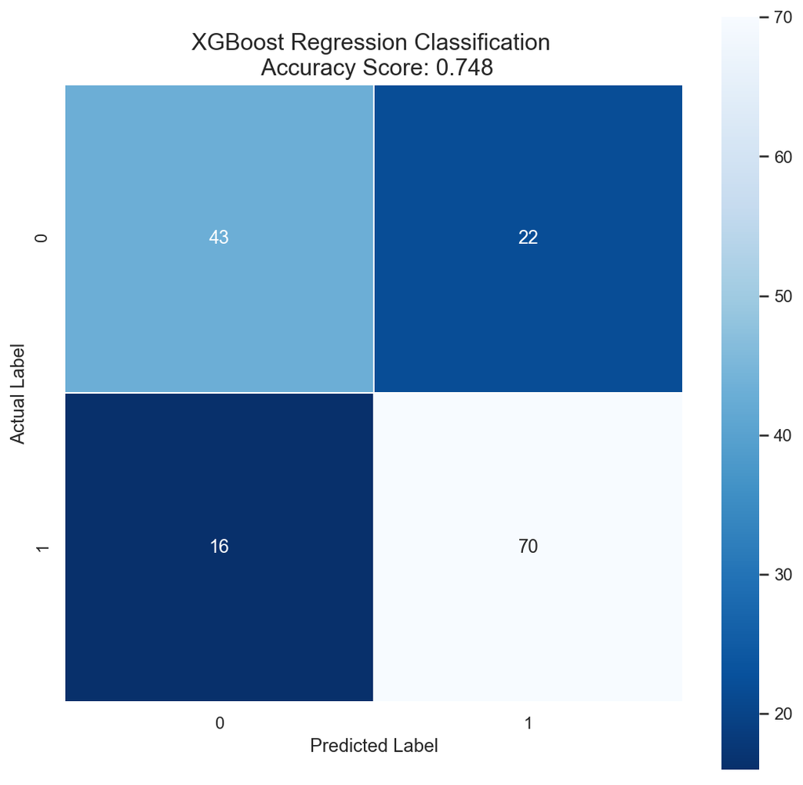

```python
xgb_classy_predictions = xgb_classy.predict(test_features) #redundant, but copied here too so I can see it
xgb_cm = confusion_matrix(test_labels, xgb_classy_predictions)
#print(cm) #this is the barebones confusion matrix

#all credit due to: Michael Galarnyk, "Logistic Regression using Python (scikit-learn)", Towards Data Science
plt.figure(figsize=(9,9))
sns.heatmap(xgb_cm, annot=True, fmt=".0f", linewidths=.5, square = True, cmap = 'Blues_r');
plt.ylabel('Actual Label');
plt.xlabel('Predicted Label');
all_sample_title = 'XGBoost Regression Classification \n Accuracy Score: {0:.3f}'.format(\
                                                                xgb_classy.score(test_features, test_labels))
plt.title(all_sample_title, size = 15)
plt.savefig('exhibit_h_xgboost_regression_confusion_matrix',dpi=300, bbox_inches='tight')
print("Accuracy: "+str(accuracy_score(test_labels, xgb_classy_predictions))) #this is just a little check at the end
print("Precision: "+str(precision_score(test_labels, xgb_classy_predictions))) #this is just a little check at the end
print("Recall: "+str(recall_score(test_labels, xgb_classy_predictions))) #this is just a little check at the end
```

Back to Top

## 📊 Logistic Regression Classification 📊

```python
#logistic regression
classification_features = labordata_processed.drop(['inlf'], axis = 1)
classification_outcome = labordata_processed.inlf
train_features, test_features, train_labels, test_labels = train_test_split(classification_features,\
                                                                            classification_outcome, test_size = 0.2)
#normalize this, since sklearn's logistic regression uses regularization
scaler = StandardScaler()
#"To determine the scaling factors and apply the scaling to the feature data:" -Codecademy
classification_train_features = scaler.fit_transform(train_features)
#"To apply the scaling to the test data:" -Codecademy
classification_test_features = scaler.transform(test_features) #we do NOT want to fit to the test

#run model
log_model = LogisticRegression(solver="liblinear") #to remove warning
log_model.fit(classification_train_features, train_labels)
print("_________Logistic Regression Classification_________")
print("")
print("Scored Against Itself")
print('Accuracy Score: {}'.format(round(log_model.score(classification_train_features, train_labels),3)))
print("")
print("Scored Against Test Data")
print('Accuracy Score: {}'.format(round(log_model.score(classification_test_features, test_labels),3)))
```

```
_________Logistic Regression Classification_________

Scored Against Itself
Accuracy Score: 0.771

Scored Against Test Data
Accuracy Score: 0.808
```

```python
#cross-val
print("_________Cross-Validation Scoring for Logistic Regression Classification_________")
print('Accuracy: {}'.format(round(cross_val_score(log_model, classification_train_features, train_labels, \
                                                                cv=10, scoring='accuracy').mean(),3)))
print('Precision: {}'.format(round(cross_val_score(log_model, classification_train_features, train_labels, \
                                                                cv=10, scoring='precision').mean(),3)))
print('Recall: {}'.format(round(cross_val_score(log_model, classification_train_features, train_labels, \
                                                                cv=10, scoring='recall').mean(),3)))
```

```
_________Cross-Validation Scoring for Logistic Regression Classification_________
Accuracy: 0.746
Precision: 0.761
Recall: 0.803
```

```python
log_regression_feature_list = []
log_regression_coef_list = []
odds_ratios = []
percent_change_in_odds = []
for i in classification_features.columns:
    log_regression_feature_list.append(i)
for i in range(len(log_model.coef_[0])):
    log_regression_coef_list.append(log_model.coef_[0][i])
for i in log_regression_coef_list:
    odds_ratios.append(np.exp(i))
for i in odds_ratios:
    percent_change_in_odds.append(round((i-1)*100,2))
```

```python
top_10_log_reg_features = pd.DataFrame(sorted(list(zip(log_regression_feature_list,log_regression_coef_list, \
                                                       percent_change_in_odds))\
       ,key = lambda x: abs(x[1]),reverse=True)[:10], columns=['Feature', 'Logistic Regression Coefficient',\
                                                              'Percent Change in Odds of Being in Labor Force'])
top_10_log_reg_features
```

|  | Feature | Logistic Regression Coefficient | Percent Change in Odds of Being in Labor Force |
| --- | --- | --- | --- |
| 0 | mtr | -1.249254 | -71.33 |
| 1 | huswage | -1.224260 | -70.60 |
| 2 | hushrs | -0.683773 | -49.53 |
| 3 | kidslt6 | -0.652633 | -47.93 |
| 4 | age | -0.561213 | -42.95 |
| 5 | exper | 0.417370 | 51.80 |
| 6 | educ | 0.398756 | 49.00 |
| 7 | expersq | 0.364379 | 43.96 |
| 8 | huseduc | -0.223389 | -20.02 |
| 9 | motheduc | 0.153784 | 16.62 |

```
Accuracy: 0.8079470198675497
Precision: 0.8152173913043478
Recall: 0.8620689655172413
```

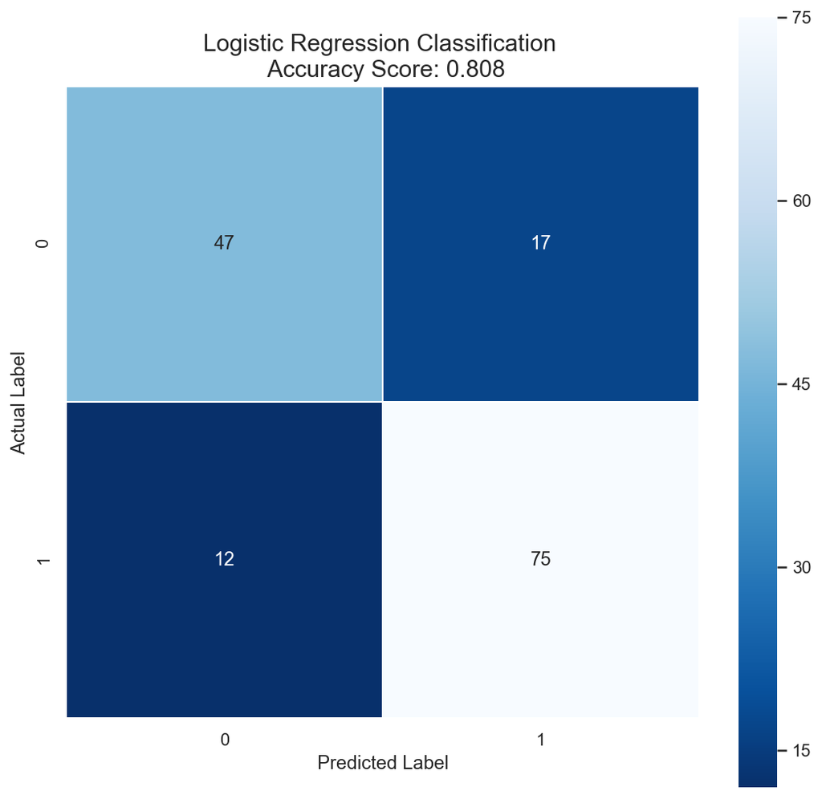

```python
log_model_predictions = log_model.predict(classification_test_features)
cm = confusion_matrix(test_labels, log_model_predictions)
#print(cm) #this is the barebones confusion matrix

#all credit due to: Michael Galarnyk, "Logistic Regression using Python (scikit-learn)", Towards Data Science
plt.figure(figsize=(9,9))
sns.heatmap(cm, annot=True, fmt=".0f", linewidths=.5, square = True, cmap = 'Blues_r');
plt.ylabel('Actual Label');
plt.xlabel('Predicted Label');
all_sample_title = 'Logistic Regression Classification \n Accuracy Score: {0:.3f}'.format(\
                                                log_model.score(classification_test_features, test_labels))
plt.title(all_sample_title, size = 15)
plt.savefig('exhibit_g_logistic_regression_confusion_matrix',dpi=300, bbox_inches='tight')
print("Accuracy: "+str(accuracy_score(test_labels, log_model_predictions))) #this is just a little check at the end
print("Precision: "+str(precision_score(test_labels, log_model_predictions))) #this is just a little check at the end
print("Recall: "+str(recall_score(test_labels, log_model_predictions))) #this is just a little check at the end
```

Back to Top

## 📊 Keras Nerual Network Classification 📊

```python
# fix random seed for reproducibility
seed = 7
np.random.seed(seed)
```

```python
#keras neural network regression
classification_features_nn = labordata_processed.drop(['inlf'], axis = 1)
classification_outcome_nn = labordata_processed.inlf
train_features_nn, test_features_nn, train_labels_nn, test_labels_mm = train_test_split(classification_features_nn,\
                                                                classification_outcome_nn, test_size = 0.2)
```

```python
#normalize this, since sklearn's logistic regression uses regularization
scaler = StandardScaler()
#"To determine the scaling factors and apply the scaling to the feature data:" -Codecademy
classification_train_features_nn = scaler.fit_transform(train_features_nn)
#"To apply the scaling to the test data:" -Codecademy
classification_test_features_nn = scaler.transform(test_features_nn) #we do NOT want to fit to the test
```

```python
def create_model(optimizer='rmsprop', init='uniform'):
    # create model
    model = Sequential()
    model.add(Dense(12, input_dim=15, activation='relu'))
    model.add(Dense(15, activation='relu'))
    model.add(Dense(1, activation='sigmoid'))
    # Compile model
    model.compile(loss='binary_crossentropy', optimizer='adam', metrics=['accuracy'])
    #model.fit(train_features, train_labels, epochs=150, batch_size=10)
    return model
```

```python
warnings.filterwarnings("ignore",category=DeprecationWarning)
# create model
model = KerasClassifier(build_fn=create_model, epochs=150, batch_size=10, verbose=0)
model.fit(train_features, train_labels, epochs=150, batch_size=10)
# evaluate using 10-fold cross validation
kfold = StratifiedKFold(n_splits=10, shuffle=True, random_state=seed)
results = cross_val_score(model, classification_train_features_nn, train_labels_nn, cv=kfold)
print(results.mean())
```

```
0.7112035788444553
```

```python
print("_________Cross-Validation Scoring for Keras Neural Network Classification_________")
print('Accuracy: {}'.format(round(cross_val_score(model, classification_train_features_nn, train_labels_nn, \
                                                                cv=10, scoring='accuracy').mean(),3)))
print('Precision: {}'.format(round(cross_val_score(model, classification_train_features_nn, train_labels_nn, \
                                                                cv=10, scoring='precision').mean(),3)))
print('Recall: {}'.format(round(cross_val_score(model, classification_train_features_nn, train_labels_nn, \
                                                                cv=10, scoring='recall').mean(),3)))
```

```
_________Cross-Validation Scoring for Keras Neural Network Classification_________
Accuracy: 0.713
Precision: 0.737
Recall: 0.797
```

```python
model.fit(classification_train_features_nn, train_labels_nn, epochs=150, batch_size=10)
```

```
<keras.callbacks.History at 0x1c85b68630>
```

```
Accuracy: 0.41721854304635764
Precision: 0.49382716049382713
Recall: 0.45977011494252873
```

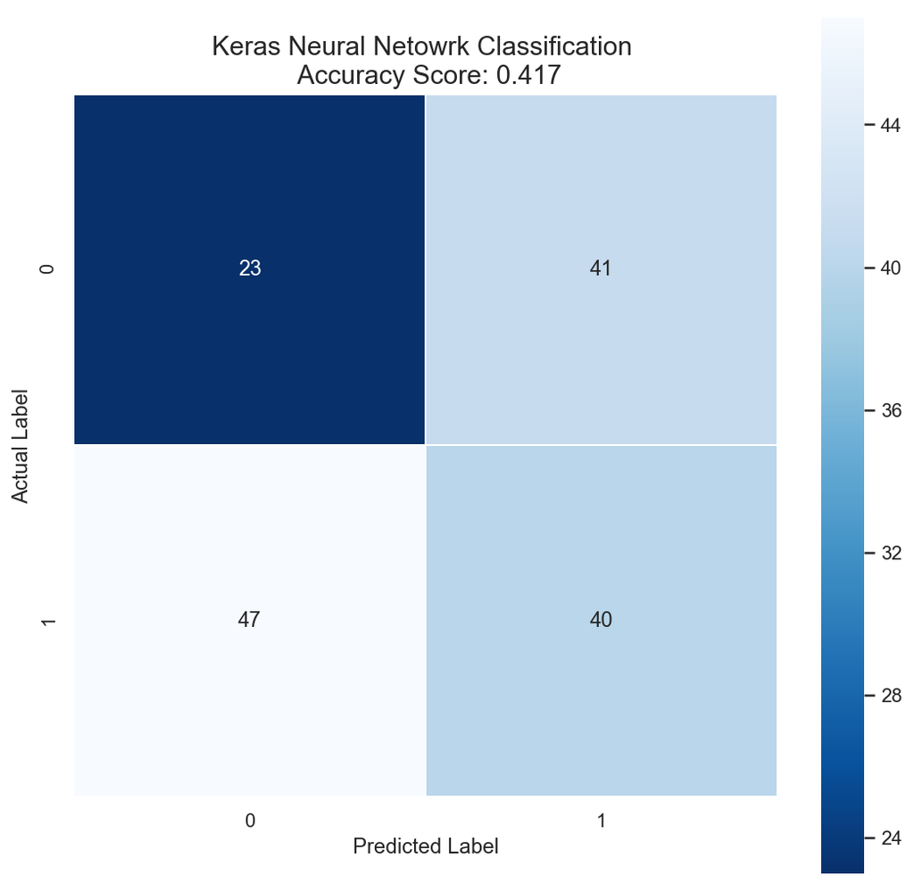

```python
#keras
model_predictions_nn = model.predict(classification_test_features_nn)
cm = confusion_matrix(test_labels, model_predictions_nn)
#print(cm) #this is the barebones confusion matrix

#all credit due to: Michael Galarnyk, "Logistic Regression using Python (scikit-learn)", Towards Data Science
plt.figure(figsize=(9,9))
sns.heatmap(cm, annot=True, fmt=".0f", linewidths=.5, square = True, cmap = 'Blues_r');
plt.ylabel('Actual Label');
plt.xlabel('Predicted Label');
all_sample_title = 'Keras Neural Netowrk Classification \n Accuracy Score: {0:.3f}'.format(\
                                                model.score(classification_test_features_nn, test_labels))
plt.title(all_sample_title, size = 15)
plt.savefig('neural_network_confusion_matrix',dpi=300, bbox_inches='tight')
print("Accuracy: "+str(accuracy_score(test_labels, model_predictions_nn))) #this is just a little check at the end
print("Precision: "+str(precision_score(test_labels, model_predictions_nn))) #this is just a little check at the end
print("Recall: "+str(recall_score(test_labels, model_predictions_nn))) #this is just a little check at the end
```

#### 👇🏾Thoughts about this? 👇🏾

- The below block of code comes from Jason Brownlee.

```python
warnings.filterwarnings("ignore",category=DeprecationWarning)
# grid search epochs, batch size and optimizer
optimizers = ['rmsprop', 'adam']
inits = ['glorot_uniform', 'normal', 'uniform']
epochs = [50, 100, 150]
batches = [5, 10, 20]
param_grid = dict(optimizer=optimizers, epochs=epochs, batch_size=batches, init=inits)
grid = GridSearchCV(estimator=model, param_grid=param_grid)
grid_result = grid.fit(train_features, train_labels)
# summarize results
print("Best: %f using %s" % (grid_result.best_score_, grid_result.best_params_))
means = grid_result.cv_results_['mean_test_score']
stds = grid_result.cv_results_['std_test_score']
params = grid_result.cv_results_['params']
for mean, stdev, param in zip(means, stds, params):
    print("%f (%f) with: %r" % (mean, stdev, param))
```

```
Best: 0.636213 using {'batch_size': 5, 'epochs': 50, 'init': 'uniform', 'optimizer': 'rmsprop'}
0.566445 (0.052454) with: {'batch_size': 5, 'epochs': 50, 'init': 'glorot_uniform', 'optimizer': 'rmsprop'}
0.528239 (0.079805) with: {'batch_size': 5, 'epochs': 50, 'init': 'glorot_uniform', 'optimizer': 'adam'}
0.471761 (0.079805) with: {'batch_size': 5, 'epochs': 50, 'init': 'normal', 'optimizer': 'rmsprop'}
0.528239 (0.079805) with: {'batch_size': 5, 'epochs': 50, 'init': 'normal', 'optimizer': 'adam'}
0.636213 (0.032536) with: {'batch_size': 5, 'epochs': 50, 'init': 'uniform', 'optimizer': 'rmsprop'}
0.471761 (0.079805) with: {'batch_size': 5, 'epochs': 50, 'init': 'uniform', 'optimizer': 'adam'}
0.476744 (0.081397) with: {'batch_size': 5, 'epochs': 100, 'init': 'glorot_uniform', 'optimizer': 'rmsprop'}
0.558140 (0.085022) with: {'batch_size': 5, 'epochs': 100, 'init': 'glorot_uniform', 'optimizer': 'adam'}
0.584718 (0.101911) with: {'batch_size': 5, 'epochs': 100, 'init': 'normal', 'optimizer': 'rmsprop'}
0.438538 (0.058214) with: {'batch_size': 5, 'epochs': 100, 'init': 'normal', 'optimizer': 'adam'}
0.471761 (0.079805) with: {'batch_size': 5, 'epochs': 100, 'init': 'uniform', 'optimizer': 'rmsprop'}
0.498339 (0.042208) with: {'batch_size': 5, 'epochs': 100, 'init': 'uniform', 'optimizer': 'adam'}
0.471761 (0.079805) with: {'batch_size': 5, 'epochs': 150, 'init': 'glorot_uniform', 'optimizer': 'rmsprop'}
0.433555 (0.052454) with: {'batch_size': 5, 'epochs': 150, 'init': 'glorot_uniform', 'optimizer': 'adam'}
0.574751 (0.093553) with: {'batch_size': 5, 'epochs': 150, 'init': 'normal', 'optimizer': 'rmsprop'}
0.581395 (0.063342) with: {'batch_size': 5, 'epochs': 150, 'init': 'normal', 'optimizer': 'adam'}
0.476744 (0.081397) with: {'batch_size': 5, 'epochs': 150, 'init': 'uniform', 'optimizer': 'rmsprop'}
0.558140 (0.120625) with: {'batch_size': 5, 'epochs': 150, 'init': 'uniform', 'optimizer': 'adam'}
0.433555 (0.052454) with: {'batch_size': 10, 'epochs': 50, 'init': 'glorot_uniform', 'optimizer': 'rmsprop'}
0.528239 (0.079805) with: {'batch_size': 10, 'epochs': 50, 'init': 'glorot_uniform', 'optimizer': 'adam'}
0.523256 (0.081397) with: {'batch_size': 10, 'epochs': 50, 'init': 'normal', 'optimizer': 'rmsprop'}
0.476744 (0.081397) with: {'batch_size': 10, 'epochs': 50, 'init': 'normal', 'optimizer': 'adam'}
0.438538 (0.058214) with: {'batch_size': 10, 'epochs': 50, 'init': 'uniform', 'optimizer': 'rmsprop'}
0.433555 (0.052454) with: {'batch_size': 10, 'epochs': 50, 'init': 'uniform', 'optimizer': 'adam'}
0.566445 (0.052454) with: {'batch_size': 10, 'epochs': 100, 'init': 'glorot_uniform', 'optimizer': 'rmsprop'}
0.498339 (0.100967) with: {'batch_size': 10, 'epochs': 100, 'init': 'glorot_uniform', 'optimizer': 'adam'}
0.523256 (0.081397) with: {'batch_size': 10, 'epochs': 100, 'init': 'normal', 'optimizer': 'rmsprop'}
0.476744 (0.081397) with: {'batch_size': 10, 'epochs': 100, 'init': 'normal', 'optimizer': 'adam'}
0.586379 (0.056357) with: {'batch_size': 10, 'epochs': 100, 'init': 'uniform', 'optimizer': 'rmsprop'}
0.566445 (0.052454) with: {'batch_size': 10, 'epochs': 100, 'init': 'uniform', 'optimizer': 'adam'}
0.528239 (0.079805) with: {'batch_size': 10, 'epochs': 150, 'init': 'glorot_uniform', 'optimizer': 'rmsprop'}
0.529900 (0.078042) with: {'batch_size': 10, 'epochs': 150, 'init': 'glorot_uniform', 'optimizer': 'adam'}
0.438538 (0.058214) with: {'batch_size': 10, 'epochs': 150, 'init': 'normal', 'optimizer': 'rmsprop'}
0.476744 (0.081397) with: {'batch_size': 10, 'epochs': 150, 'init': 'normal', 'optimizer': 'adam'}
0.438538 (0.058214) with: {'batch_size': 10, 'epochs': 150, 'init': 'uniform', 'optimizer': 'rmsprop'}
0.476744 (0.081397) with: {'batch_size': 10, 'epochs': 150, 'init': 'uniform', 'optimizer': 'adam'}
0.549834 (0.109166) with: {'batch_size': 20, 'epochs': 50, 'init': 'glorot_uniform', 'optimizer': 'rmsprop'}
0.523256 (0.081397) with: {'batch_size': 20, 'epochs': 50, 'init': 'glorot_uniform', 'optimizer': 'adam'}
0.544851 (0.078925) with: {'batch_size': 20, 'epochs': 50, 'init': 'normal', 'optimizer': 'rmsprop'}
0.471761 (0.079805) with: {'batch_size': 20, 'epochs': 50, 'init': 'normal', 'optimizer': 'adam'}
0.433555 (0.052454) with: {'batch_size': 20, 'epochs': 50, 'init': 'uniform', 'optimizer': 'rmsprop'}
0.471761 (0.079805) with: {'batch_size': 20, 'epochs': 50, 'init': 'uniform', 'optimizer': 'adam'}
0.534884 (0.078619) with: {'batch_size': 20, 'epochs': 100, 'init': 'glorot_uniform', 'optimizer': 'rmsprop'}
0.561462 (0.058214) with: {'batch_size': 20, 'epochs': 100, 'init': 'glorot_uniform', 'optimizer': 'adam'}
0.476744 (0.081397) with: {'batch_size': 20, 'epochs': 100, 'init': 'normal', 'optimizer': 'rmsprop'}
0.475083 (0.080802) with: {'batch_size': 20, 'epochs': 100, 'init': 'normal', 'optimizer': 'adam'}
0.578073 (0.083920) with: {'batch_size': 20, 'epochs': 100, 'init': 'uniform', 'optimizer': 'rmsprop'}
0.566445 (0.052454) with: {'batch_size': 20, 'epochs': 100, 'init': 'uniform', 'optimizer': 'adam'}
0.436877 (0.053243) with: {'batch_size': 20, 'epochs': 150, 'init': 'glorot_uniform', 'optimizer': 'rmsprop'}
0.566445 (0.052454) with: {'batch_size': 20, 'epochs': 150, 'init': 'glorot_uniform', 'optimizer': 'adam'}
0.471761 (0.079805) with: {'batch_size': 20, 'epochs': 150, 'init': 'normal', 'optimizer': 'rmsprop'}
0.438538 (0.058214) with: {'batch_size': 20, 'epochs': 150, 'init': 'normal', 'optimizer': 'adam'}
0.566445 (0.052454) with: {'batch_size': 20, 'epochs': 150, 'init': 'uniform', 'optimizer': 'rmsprop'}
0.576412 (0.042117) with: {'batch_size': 20, 'epochs': 150, 'init': 'uniform', 'optimizer': 'adam'}
```

Back to Top

# Thank you so much for your time and consideration!

## George John Jordan Thomas Aquinas Hayward, Optimist

[figure not shown]

[#TheLordAlwaysDelivers](https://youtu.be/in2MOJ-Hb8g)